# Analyzing Sales Data from Ecommerce Website

Author: [Giang Son Nguyen](https://www.linkedin.com/in/nguyengiangson/).  
Date: 26.05.2021

# Table of Contents

## Overview

In this project, I've been given 10-day sales data (from *September 2018*) of an undisclosed ecommerce website in Vietnam.

My objective is to perform several data analysis tasks (including one data wrangling task and one case study - more details on the tasks below) to gain key business insights. I'll also be providing some commentaries/ explanations wherever neccessary. The data is a bit limited, but the large volume of interactions still enable some interesting inferences.

Note: The product category names (**merchant** column) are in Vietnamese, so I will translate them when making interpretations about the data. Really sorry for this inconsistency 😥.

## Task 0: Import necessary libraries and load data

```python
import numpy as np
import pandas as pd
pd.options.mode.chained_assignment = None
import matplotlib.pyplot as plt
import seaborn as sns
import plotly.graph_objects as go
import plotly.express as px
from itertools import combinations, permutations
import time
```

```python
prices_df = pd.read_csv('prices.csv')
sales_df = pd.read_csv('sales.csv')
df = pd.read_csv('case_study.csv',low_memory=False)

start_time= time.process_time()
```

## Task 1: Data Wrangling

### Questions:

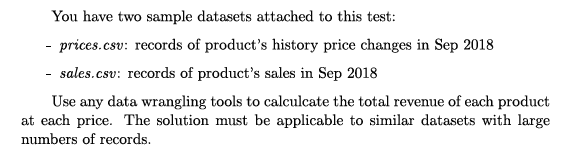

### Answers:

#### 0. Exploratory Data Analysis and Preparation

```python
prices_df.head()
```

|  | product_id | old_price | new_price | updated_at |
| --- | --- | --- | --- | --- |
| 0 | 64 | 270000 | 239000 | 9/10/18 16:37 |
| 1 | 3954203 | 60000 | 64000 | 9/11/18 11:54 |
| 2 | 3954203 | 60500 | 57500 | 9/17/18 22:59 |
| 3 | 3954203 | 64000 | 60500 | 9/15/18 3:49 |
| 4 | 3954203 | 68800 | 60000 | 9/10/18 16:32 |

```python
sales_df.head()
```

|  | product_id | ordered_at | quantity_ordered |
| --- | --- | --- | --- |
| 0 | 3998909 | 9/18/18 17:51 | 1 |
| 1 | 3998909 | 9/18/18 12:52 | 1 |
| 2 | 3998909 | 9/18/18 11:33 | 1 |
| 3 | 3998909 | 9/18/18 18:47 | 1 |
| 4 | 3998909 | 9/18/18 17:36 | 1 |

```python
# Checking the data types of each columns in the 2 dataframes shows that
# the *updated_at* and *ordered_at* columns are in string format.
print('price_df ' + '*'*20)
print(prices_df.dtypes)
print('sales_df ' + '*'*20)
print(sales_df.dtypes)
```

```
price_df ********************
product_id     int64
old_price      int64
new_price      int64
updated_at    object
dtype: object
sales_df ********************
product_id           int64
ordered_at          object
quantity_ordered     int64
dtype: object
```

```python
# Let's format them to datetime for easier processing.
prices_df['updated_at'] = pd.to_datetime(prices_df['updated_at'], infer_datetime_format = True)
sales_df['ordered_at'] = pd.to_datetime(sales_df['ordered_at'], infer_datetime_format = True)
# While we're at it, let's change the dtype for *product_id* too (from int to str).
prices_df['product_id'] = prices_df['product_id'].astype('str')
sales_df['product_id'] = sales_df['product_id'].astype('str')
```

```python
# the results
print(prices_df.dtypes)
print(sales_df.dtypes)
```

```
product_id            object
old_price              int64
new_price              int64
updated_at    datetime64[ns]
dtype: object
product_id                  object
ordered_at          datetime64[ns]
quantity_ordered             int64
dtype: object
```

```python
# I also sort the prices_df by *updated_at*
# so it's easier to find the right price later on
prices_df_sorted = prices_df.sort_values('updated_at', ascending = False)
prices_df_sorted.head()
```

|  | product_id | old_price | new_price | updated_at |
| --- | --- | --- | --- | --- |
| 2 | 3954203 | 60500 | 57500 | 2018-09-17 22:59:00 |
| 8 | 4085861 | 53500 | 52000 | 2018-09-17 22:59:00 |
| 10 | 4085861 | 58000 | 53500 | 2018-09-17 03:35:00 |
| 5 | 3998909 | 15500 | 16500 | 2018-09-16 05:09:00 |
| 12 | 4085861 | 62500 | 58000 | 2018-09-15 03:51:00 |

#### 1. Finding the newest prices for each product at each timestamp

*Explainining my logic:*  
The price for each product at the time of order will be determined in one of two ways:

1. If there exists an adjustment that ocurred *right before* the **ordered_at** time, the price will be the **new_price** of that adjustment
2. If there's not an adjustment before, then the price will be the **old_price** of the adjustments that occurred *right after* the **ordered_at** time

*So, all I have to do is:*

1. Loop through each row in the sales_df, find the right price for the product at the specific order time using the above logic. The for loop is noot the most efficient method but it gets the work done.
2. Calculate a new column **revenue**. Obviously, **`revenue = price × quantity_ordered`**. (I prefer my code to be clear so I decided to make this a separate step outside of the for loop)
3. Sum the *revenue* column by each **product_id** and **price**.

```python
# finding the unit price.
sales_df['price'] = np.zeros(sales_df.shape[0])
for row in range(sales_df.shape[0]): # loop through each row
    # find the product_id and order_at time
    product_id = sales_df.iloc[row]['product_id']
    ordered_at = sales_df.iloc[row]['ordered_at']
    # the conditions for adjustments before 'ordered_at' (logic 1)
    mask_new = (prices_df_sorted['product_id'] == product_id) & (prices_df_sorted['updated_at'] < ordered_at)
    # the conditions for adjustments after 'ordered_at' (logic 2)
    mask_old = (prices_df_sorted['product_id'] == product_id) & (prices_df_sorted['updated_at'] > ordered_at)

    # find the adjustments in the prices_df
    new_price = prices_df_sorted[mask_new]['new_price']
    old_price = prices_df_sorted[mask_old]['old_price']

    if len(new_price) > 0 :
        # if there is adjustment before, than the price will be the new_price of the newest adjustment
        price = new_price.iloc[0]
    else:
        # if there is no adjustment before, than the price will be the old_price of the oldest adjustment
        price = old_price.iloc[-1]
    sales_df['price'].iloc[row] = price

# calculate revenue
sales_df['revenue'] = sales_df['quantity_ordered'] * sales_df['price']
```

```python
sales_df.head()
```

|  | product_id | ordered_at | quantity_ordered | price | revenue |
| --- | --- | --- | --- | --- | --- |
| 0 | 3998909 | 2018-09-18 17:51:00 | 1 | 16500.0 | 16500.0 |
| 1 | 3998909 | 2018-09-18 12:52:00 | 1 | 16500.0 | 16500.0 |
| 2 | 3998909 | 2018-09-18 11:33:00 | 1 | 16500.0 | 16500.0 |
| 3 | 3998909 | 2018-09-18 18:47:00 | 1 | 16500.0 | 16500.0 |
| 4 | 3998909 | 2018-09-18 17:36:00 | 1 | 16500.0 | 16500.0 |

```python
# Calculating ther revenue and quantity_order for each product at each price point.
# I also included the sales quantity for reference
sales_df.groupby(['product_id','price']).agg({'revenue':'sum','quantity_ordered':'sum'})
```

| product_id | price | revenue | quantity_ordered |
| --- | --- | --- | --- |
| 3954203 | 57500.0 | 57500.0 | 1 |
|  | 60000.0 | 180000.0 | 3 |
|  | 64000.0 | 640000.0 | 10 |
| 3998909 | 15500.0 | 15500.0 | 1 |
|  | 16500.0 | 231000.0 | 14 |
|  | 17000.0 | 34000.0 | 2 |
| 4085861 | 52000.0 | 1040000.0 | 20 |
|  | 53500.0 | 2140000.0 | 40 |
|  | 58000.0 | 2204000.0 | 38 |
|  | 60000.0 | 180000.0 | 3 |
|  | 62500.0 | 1812500.0 | 29 |
|  | 67000.0 | 871000.0 | 13 |
| 64 | 239000.0 | 956000.0 | 4 |

## Task 2: Case Study

### Questions:

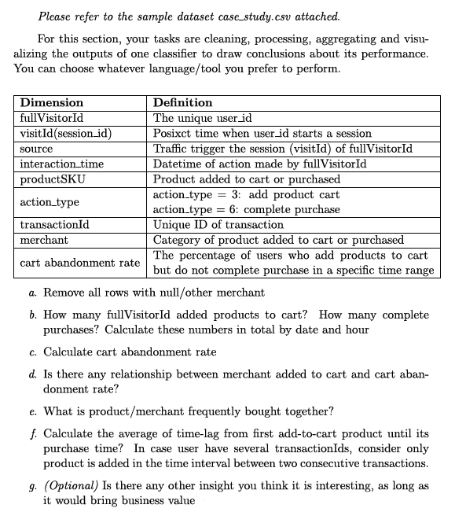

### Answers:

#### 0. Data Preparation

```python
df.head()
```

|  | fullVisitorid | visitId | source | interaction_time | productSKU | action_type | transactionId | merchant |
| --- | --- | --- | --- | --- | --- | --- | --- | --- |
| 0 | 10796433617570240226 | 1537231206 | FB | 2018-09-18 08:05:10 | 276921 | 3 | NaN | Sách Tiếng Việt |
| 1 | 3420023669829788288 | 1537339917 | FB | 2018-09-19 13:53:09 | 352156 | 3 | NaN | Sách Tiếng Việt |
| 2 | 260086599438307401 | 1536730102 | FB | 2018-09-12 12:49:53 | 392955 | 3 | NaN | Làm đẹp - Sức khỏe |
| 3 | 3156776568682643722 | 1536885003 | FB | 2018-09-14 07:30:17 | 393079 | 3 | NaN | Làm đẹp - Sức khỏe |
| 4 | 610658073725040936 | 1536882984 | FB | 2018-09-14 06:58:34 | 393079 | 3 | NaN | Làm đẹp - Sức khỏe |

```python
df.shape
```

```
(300000, 8)
```

```python
# I change the dtypes for some columns, similar to the first task
df['interaction_time'] = pd.to_datetime(df['interaction_time'])

df['fullVisitorid'] = df['fullVisitorid'].astype('str')
df['visitId'] = df['visitId'].astype('str')
df['productSKU'] = df['productSKU'].astype('str')
df['action_type'] = df['action_type'].astype('str')
df['transactionId'] = df['transactionId'].astype('str')
```

#### a. Remove all rows with null/ other merchant

```python
df.dropna(subset = ['merchant'], inplace = True)
df.shape
# the number of rows has decreased
```

```
(279621, 8)
```

#### b. How many fullVisitorId added products to cart? How many complete purchases? Calculate these number in total by date and hour.

```python
# b. How many fullVisitorId added products to cart?
added_to_cart = df[df['action_type']== '3']['fullVisitorid'].nunique()
print("fullVisitorId added products to cart: ", added_to_cart)
```

```
fullVisitorId added products to cart:  149572
```

```python
# How many complete purchases?
completed_purchase = df[df['action_type']== '6']['fullVisitorid'].nunique()
print("fullVisitorId completed purchases: ", completed_purchase)
```

```
fullVisitorId completed purchases:  32185
```

```python
# Calculate these number in total by date and hour.
df['date'] = df['interaction_time'].dt.date
df['hour'] = df['interaction_time'].dt.hour
```

```python
df[df['action_type']== '3'].groupby(['date','hour']).agg({'fullVisitorid': pd.Series.nunique})
```

| date | hour | fullVisitorid |
| --- | --- | --- |
| 2018-09-10 | 0 | 549 |
|  | 1 | 228 |
|  | 2 | 116 |
|  | 3 | 73 |
|  | 4 | 81 |
| ... | ... | ... |
| 2018-09-19 | 19 | 1009 |
|  | 20 | 1274 |
|  | 21 | 1346 |
|  | 22 | 1224 |
|  | 23 | 790 |

240 rows × 1 columns

```python
df[df['action_type']== '6'].groupby(['date','hour']).agg({'fullVisitorid': pd.Series.nunique})
```

| date | hour | fullVisitorid |
| --- | --- | --- |
| 2018-09-10 | 0 | 79 |
|  | 1 | 40 |
|  | 2 | 17 |
|  | 3 | 10 |
|  | 4 | 10 |
| ... | ... | ... |
| 2018-09-19 | 19 | 157 |
|  | 20 | 174 |
|  | 21 | 212 |
|  | 22 | 191 |
|  | 23 | 114 |

239 rows × 1 columns

#### c. Calculate cart abandonment rate

```python
abandonment_rate = (added_to_cart - completed_purchase)/added_to_cart
print("The average abandonment rate is: ", round(abandonment_rate*100,2), "%")
```

```
The average abandonment rate is:  78.48 %
```

#### d. Is there any relationship between merchant added to cart and cart abandonment rate?

```python
# Create a df of added_to_cart action (action_type = 3), grouped by merchant
df_merchant_added_to_cart = df[df['action_type'] == '3'].groupby('merchant')[['merchant']].count()
df_merchant_added_to_cart.columns = ['added_to_cart']

# Create a df of completed_purchase action (action_type = 6), grouped by merchant
df_merchant_completed_purchase = df[df['action_type'] == '6'].groupby('merchant')[['merchant']].count()
df_merchant_completed_purchase.columns = ['completed_purchase']
```

```python
# Merge tham together, than calculate the abandonment rate for each type of merchant
df_merchant = pd.merge(df_merchant_added_to_cart,df_merchant_completed_purchase, on = 'merchant').reset_index()
df_merchant['abandonment_rate'] = (df_merchant['added_to_cart'] - df_merchant['completed_purchase'])/df_merchant['added_to_cart']
```

```python
# Sorting merchant by abandonment rate
df_merchant = df_merchant[df_merchant['abandonment_rate'] >0].sort_values('abandonment_rate', ascending = False)
df_merchant.head(10)
```

|  | merchant | added_to_cart | completed_purchase | abandonment_rate |
| --- | --- | --- | --- | --- |
| 3 | Laptop & PC | 997 | 56 | 0.943831 |
| 21 | Điện thoại - Máy tính bảng | 7577 | 567 | 0.925168 |
| 19 | Xe máy, ô tô, xe đạp | 2979 | 229 | 0.923129 |
| 20 | Điện lạnh | 1302 | 123 | 0.905530 |
| 16 | Tivi - Audio | 1837 | 192 | 0.895482 |
| 15 | Thời trang | 15097 | 1580 | 0.895343 |
| 14 | Thể Thao & Dã Ngoại | 5385 | 629 | 0.883194 |
| 0 | Bách Hóa Online | 14306 | 2098 | 0.853348 |
| 5 | Máy ảnh & Phụ kiện | 1451 | 218 | 0.849759 |
| 4 | Làm đẹp - Sức khỏe | 21737 | 3497 | 0.839122 |

```python
# Setting the style for sns plot. I personally prefer big plots so figsize will be (16,10)
sns.set(style='whitegrid',
       palette="deep",
       font_scale=1.1,
       rc={"figure.figsize": [16, 10]}
      )
```

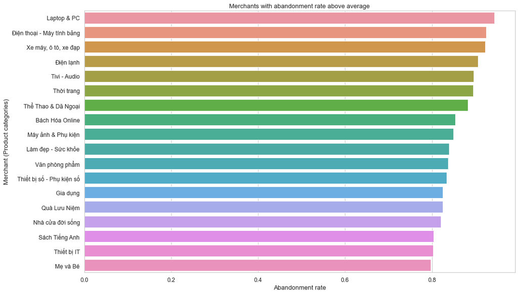

```python
# Plot the merchants whose abandonment rates are above average
ax = sns.barplot(data = df_merchant[df_merchant['abandonment_rate'] > abandonment_rate], x= 'abandonment_rate', y = 'merchant')
ax.set_title('Merchants with abandonment rate above average')
ax.set_xlabel("Abandonment rate")
ax.set_ylabel("Merchant (Product categories)")
plt.show()
```

**Quick comment:** The merchants with the highest abandonment rates are product categories that are typically high-priced (at least in Vietnam):

1. Laptop & PC
2. Smartphones - Tablets
3. Motorbikes-Car-Bikes
4. Household Applicances
5. TV - Audio

#### e. What product/merchant is frequently bought together?

```python
# In this question, we only care about transactions where
# the purchases have been completed and at least 2 types of products are involved
# which means, action_type = 6 the transactionId must appear in at least 2 different rows

# Let's create a dataframe consisting solely of the transactions that fit our description
df_duplicate = df[(df['transactionId'].duplicated(keep=False)) & (df['action_type']== '6') & (df['merchant'] != 'Promotion')][['transactionId','merchant']]
df_duplicate.drop_duplicates(inplace = True)
df_duplicate.head()
```

|  | transactionId | merchant |
| --- | --- | --- |
| 120 | 754835353 | Sách Tiếng Việt |
| 123 | 754835353 | Làm đẹp - Sức khỏe |
| 182 | 246993893 | Xe máy, ô tô, xe đạp |
| 396 | 538738164 | Sách Tiếng Việt |
| 398 | 200325610 | Sách Tiếng Việt |

```python
# Define a function that find the pairs of product
# You can fine more explaination here: https://youtu.be/iDV0Zh6HDGc
def find_pairs(x):
    pairs = pd.DataFrame(list(permutations(x.values,2)), columns = ['item_1','item_2'])
    return pairs
```

```python
# Create a dataframe consisting of all the possible combo
df_combo = df_duplicate.groupby('transactionId')['merchant'].apply(find_pairs).reset_index(drop = True)

# Calculate the frequency of them being bought together
df_combo = df_combo.groupby(['item_1','item_2']).size().reset_index()
df_combo.columns = ['item_1','item_2','frequency']
df_combo.sort_values('frequency',ascending = False,inplace = True)

# Create a new column for the combo name
df_combo['combo']= df_combo['item_1'] + ' & ' + df_combo['item_2']
df_combo.head()
```

|  | item_1 | item_2 | frequency | combo |
| --- | --- | --- | --- | --- |
| 135 | Sách Tiếng Việt | Văn phòng phẩm | 185 | Sách Tiếng Việt & Văn phòng phẩm |
| 211 | Văn phòng phẩm | Sách Tiếng Việt | 185 | Văn phòng phẩm & Sách Tiếng Việt |
| 54 | Làm đẹp - Sức khỏe | Sách Tiếng Việt | 129 | Làm đẹp - Sức khỏe & Sách Tiếng Việt |
| 124 | Sách Tiếng Việt | Làm đẹp - Sức khỏe | 129 | Sách Tiếng Việt & Làm đẹp - Sức khỏe |
| 76 | Mẹ và Bé | Sách Tiếng Việt | 115 | Mẹ và Bé & Sách Tiếng Việt |

```python
# You'll notice that each category is shown twice (once as item_1 & item_2 and once as item_2 & item_1)
# so we only need to take the even rows of that dataframe
df_combo = df_combo[['combo','frequency']][::2]
df_combo.head()
```

|  | combo | frequency |
| --- | --- | --- |
| 135 | Sách Tiếng Việt & Văn phòng phẩm | 185 |
| 54 | Làm đẹp - Sức khỏe & Sách Tiếng Việt | 129 |
| 76 | Mẹ và Bé & Sách Tiếng Việt | 115 |
| 129 | Sách Tiếng Việt & Sách Tiếng Anh | 88 |
| 131 | Sách Tiếng Việt & Thiết bị số - Phụ kiện số | 74 |

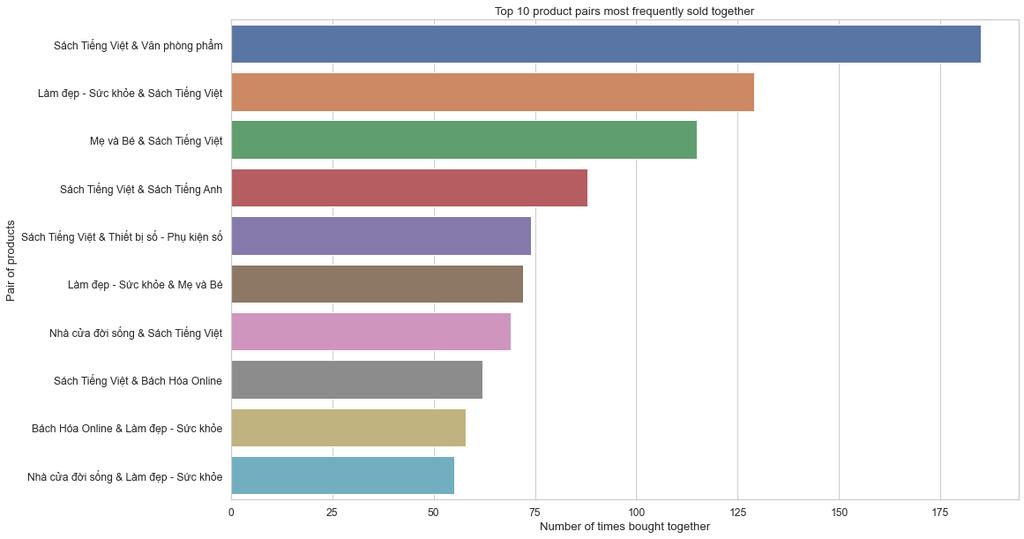

```python
# Plotting the pairs and their frequency of being bought together
ax = sns.barplot(data = df_combo.head(10), y = 'combo', x = 'frequency')
ax.set_title("Top 10 product pairs most frequently sold together")
ax.set_ylabel("Pair of products")
ax.set_xlabel("Number of times bought together")
plt.show()
```

**Quick comment:** The most frequently brough together pair is: Vietnamese books & office supplies (pens, paper, etc...)

Surprisingly, Vietnamese books appear in 7 of the top 10 pairs. However, I wouldn't read too much into this because it's very likely that customers were buying books on this site and just happened to add something else in the same order (trust me, I've been there too).

#### f.Calculate the average of time-lag from first add-to-cart product until its purchase time?

In case user have several transactionIds, consider only product is added in the time interval between two consecutive transactions

```python
df_purchases = df[df['action_type'] == '6'][['fullVisitorid','source','interaction_time','productSKU','merchant']]
df_purchases.head()
```

|  | fullVisitorid | source | interaction_time | productSKU | merchant |
| --- | --- | --- | --- | --- | --- |
| 30 | 1917931473058109470 | FB | 2018-09-13 21:41:06 | 888949 | Làm đẹp - Sức khỏe |
| 38 | 806808667484303094 | FB | 2018-09-13 17:10:54 | 1320851 | Làm đẹp - Sức khỏe |
| 41 | 6875896961917464162 | FB | 2018-09-14 12:05:20 | 1320851 | Làm đẹp - Sức khỏe |
| 120 | 3278199159587501495 | FB | 2018-09-14 17:40:11 | 1694077 | Sách Tiếng Việt |
| 123 | 3278199159587501495 | FB | 2018-09-14 17:40:11 | 2738499 | Làm đẹp - Sức khỏe |

```python
df_to_cart = df[df['action_type'] == '3'].groupby(['fullVisitorid','productSKU'])['interaction_time'].min().reset_index()
df_to_cart.head()
```

|  | fullVisitorid | productSKU | interaction_time |
| --- | --- | --- | --- |
| 0 | 10000047349280622264 | 3630829 | 2018-09-16 15:25:17 |
| 1 | 10000047349280622264 | 4310671 | 2018-09-16 15:24:35 |
| 2 | 10000428164449421463 | 1745163 | 2018-09-19 08:57:01 |
| 3 | 10000777959432528570 | 3953405 | 2018-09-15 02:33:26 |
| 4 | 10000784981573917907 | 1408705 | 2018-09-11 19:42:47 |

```python
df_timelag = pd.merge(df_purchases,df_to_cart, how = 'left', on = ['fullVisitorid','productSKU'])
df_timelag.rename(columns = {'interaction_time_x': 'completed_purchase_time', 'interaction_time_y': 'added_to_cart_time'}, inplace = True)

# Calculate the time lag between the first added to cart product and the time of completing purchase
df_timelag['time_lag'] = df_timelag['completed_purchase_time'] - df_timelag['added_to_cart_time']

# Some orders don't have an add to cart time (?), so I assume the purchase is made immediately after the product is added to cart
# which means the time_lag for those transactions is 0
df_timelag['time_lag'].fillna(pd.Timedelta(seconds=0), inplace = True)
# convert the time_lag to minutes
df_timelag['time_lag'] = df_timelag['time_lag'].dt.total_seconds()/60
df_timelag.head()
```

|  | fullVisitorid | source | completed_purchase_time | productSKU | merchant | added_to_cart_time | time_lag |
| --- | --- | --- | --- | --- | --- | --- | --- |
| 0 | 1917931473058109470 | FB | 2018-09-13 21:41:06 | 888949 | Làm đẹp - Sức khỏe | NaT | 0.000000 |
| 1 | 806808667484303094 | FB | 2018-09-13 17:10:54 | 1320851 | Làm đẹp - Sức khỏe | 2018-09-13 17:06:12 | 4.700000 |
| 2 | 6875896961917464162 | FB | 2018-09-14 12:05:20 | 1320851 | Làm đẹp - Sức khỏe | 2018-09-14 12:04:51 | 0.483333 |
| 3 | 3278199159587501495 | FB | 2018-09-14 17:40:11 | 1694077 | Sách Tiếng Việt | 2018-09-14 17:38:25 | 1.766667 |
| 4 | 3278199159587501495 | FB | 2018-09-14 17:40:11 | 2738499 | Làm đẹp - Sức khỏe | 2018-09-14 17:39:48 | 0.383333 |

```python
print("Average time lag between first add-to-cart product and purchase time is: ", round(df_timelag['time_lag'].mean(),2), ' minutes')
```

```
Average time lag between first add-to-cart product and purchase time is:  86.09  minutes
```

```python
# find the time lag for each merchant
time_lag_by_merchant = df_timelag.groupby('merchant')['time_lag'].mean().reset_index()
time_lag_by_merchant.sort_values('time_lag', ascending = False, inplace = True)
time_lag_by_merchant.head(10)
```

|  | merchant | time_lag |
| --- | --- | --- |
| 8 | Mẹ và Bé | 270.320141 |
| 23 | Điện lạnh | 201.059621 |
| 20 | Voucher - Dịch vụ | 180.520200 |
| 24 | Điện thoại - Máy tính bảng | 127.247443 |
| 22 | Xe máy, ô tô, xe đạp | 120.698836 |
| 13 | Sách Tiếng Việt | 93.567515 |
| 4 | Gia dụng | 92.332197 |
| 21 | Văn phòng phẩm | 91.076305 |
| 16 | Thể Thao & Dã Ngoại | 85.154849 |
| 11 | Quà Lưu Niệm | 76.715783 |

```python
fig = px.bar(time_lag_by_merchant.head(10), x="time_lag", y="merchant",
             title='Average time lag by merchant',
             labels = {'time_lag': 'Time lag between add-to-cart and purchase (minutes)',
                      'merchant': 'Merchant (Product category)'})
fig.update_layout(title_x = 0.5)
fig.show()
```

[interactive chart not shown]

It's rather difficult to make interprations about this question, because I have many doubts about (1) the data and (2) my calculation method. So I've leave it to the readers to make sense of this.

#### g. Is there any other insight that you think is interesting?

```python
# Let's examine the number of transactions completed, grouped by time of day
df_purchase_by_hr = df[df['action_type'] == '6'].groupby('hour')['transactionId'].nunique().reset_index()
df_purchase_by_hr.columns = ['hour','number_of_purchases']
```

```python
df_purchase_by_hr
```

|  | hour | number_of_purchases |
| --- | --- | --- |
| 0 | 0 | 611 |
| 1 | 1 | 303 |
| 2 | 2 | 137 |
| 3 | 3 | 78 |
| 4 | 4 | 99 |
| 5 | 5 | 139 |
| 6 | 6 | 286 |
| 7 | 7 | 663 |
| 8 | 8 | 1714 |
| 9 | 9 | 2617 |
| 10 | 10 | 3295 |
| 11 | 11 | 2996 |
| 12 | 12 | 2231 |
| 13 | 13 | 2644 |
| 14 | 14 | 2800 |
| 15 | 15 | 2619 |
| 16 | 16 | 2394 |
| 17 | 17 | 1791 |
| 18 | 18 | 1340 |
| 19 | 19 | 1308 |
| 20 | 20 | 1676 |
| 21 | 21 | 1885 |
| 22 | 22 | 1725 |
| 23 | 23 | 1222 |

```python
# Plotting the data on a line graph
fig = px.line(df_purchase_by_hr, x="hour", y="number_of_purchases",
             title='Number of purchases completed by time of day')
fig.update_layout(title_x = 0.5)
fig.show()
```

[interactive chart not shown]

This graph is **interactive**! Try moving your mouse to interacte with it.

**Quick comment:** A very apparent peak-time for orders made is the middle of the day (10 AM in particular). On another note, not a lot of people were online shopping after 9 PM as the number of orders dipped throughout the night. Implications? Maybe set some promotion program at those hours where interest peaked.

## Conclusion

In this notebook, I have analyzed sales data from an ecommerce website and obtained some useful insights. Hopefully you have gained something interesting from this too. If you have any comments, please let me know.

# Thank you for reading.

```python
end_time = time.process_time()
elapsed_time = end_time - start_time
print('This notebook was run in: ', round(elapsed_time,2), ' seconds')
```

```
This notebook was run in:  17.47  seconds
```